# R Notebook

```r
library(tidyverse)
source("prob.R")
```

```r
tosscoin(1) %>%
  mutate(p = 1/n())
```

| toss1 | p |
| --- | --- |
| H | 0.5 |
| T | 0.5 |

What is the probability of each of the 8 possible outcomes when tossing 3 coins?

```r
s_three_coins_labelled <- tosscoin(3) %>%
  mutate(outcome = str_c(toss1, toss2, toss3, sep = ""),
         prob = 1 / n())

s_three_coins
```

| toss1 | toss2 | toss3 | outcome | prob |
| --- | --- | --- | --- | --- |
| H | H | H | HHH | 0.125 |
| T | H | H | THH | 0.125 |
| H | T | H | HTH | 0.125 |
| T | T | H | TTH | 0.125 |
| H | H | T | HHT | 0.125 |
| T | H | T | THT | 0.125 |
| H | T | T | HTT | 0.125 |
| T | T | T | TTT | 0.125 |

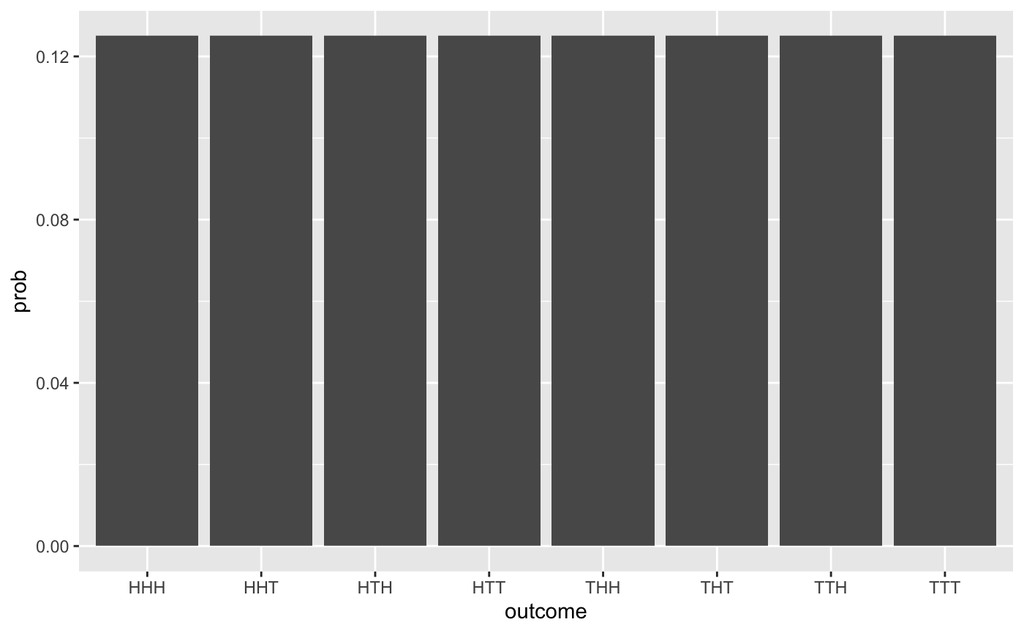

```r
s_three_coins_labelled %>%
  ggplot(aes(x = outcome,
             y = prob)) +
  geom_col()
```

- All the bars are the same height as they have the same probability
- This is a **UNIFORM** distribution

What are the probabilities of getting 0 heads, 1 head, 2 heads, or 3 heads when tossing 3 coins?

```r
s_three_coins <- tosscoin(3) %>%
  mutate(outcome = str_c(toss1, toss2, toss3, sep = ""),
         prob = 1 / n())

s_diff_h <- s_three_coins %>%
  mutate(n_heads = str_count(outcome, "H")) %>%
  group_by(n_heads) %>%
  summarise(prob = sum(prob))

s_diff_h
```

| n_heads | prob |
| --- | --- |
| 0 | 0.125 |
| 1 | 0.375 |
| 2 | 0.375 |
| 3 | 0.125 |

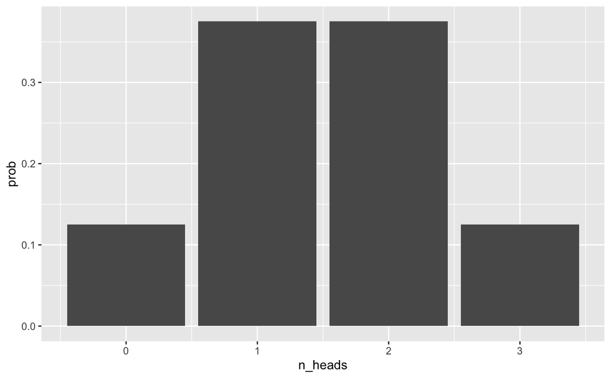

```r
s_diff_h %>%
  ggplot(aes(x = n_heads,
             y = prob)) +
  geom_col()
```

The probability distribution is **no longer** uniform We would call this a **discrete** probability distrubtion (finite/ countable)

General Properties of **discrete** probability distributions:

- x-axis = outcomes
- y-axis = probability
- the probabilities *must* sum to 1

$$\sum{p(x)} = 1$$

## Measures of Centrality

- mean
- median
- mode

These are all expressing where the centre of our distribution is. The are different measures of the middle of a distribution

```r
library(janitor)
library(lubridate)
```

```r
aircon <- read_csv("data/AirConSales.csv")
aircon <- aircon %>%
  clean_names() %>%
  mutate(date = mdy(date))

aircon
```

| date | units_sold |
| --- | --- |
| 2018-06-05 | 0 |
| 2018-06-06 | 1 |
| 2018-06-07 | 0 |
| 2018-06-08 | 9 |
| 2018-06-09 | 3 |
| 2018-06-10 | 3 |
| 2018-06-11 | 4 |
| 2018-06-12 | 3 |
| 2018-06-13 | 4 |
| 2018-06-14 | 11 |

[output cut: 27 more lines]

for every date, we have how many units were sold. we are interested in how often it is to sell a certain number of units e.g. how often/likely is it that on any day we sell 3 units

```r
sales_freq
```

```
 units_sold n    percent
          0 3 0.08108108
          1 2 0.05405405
          2 2 0.05405405
          3 9 0.24324324
          4 8 0.21621622
          6 3 0.08108108
          8 1 0.02702703
          9 1 0.02702703
         10 2 0.05405405
         11 3 0.08108108
         12 2 0.05405405
         43 1 0.02702703
```

percent in the tabyl doesn’t refer to a probability / percent, but a relative frequency

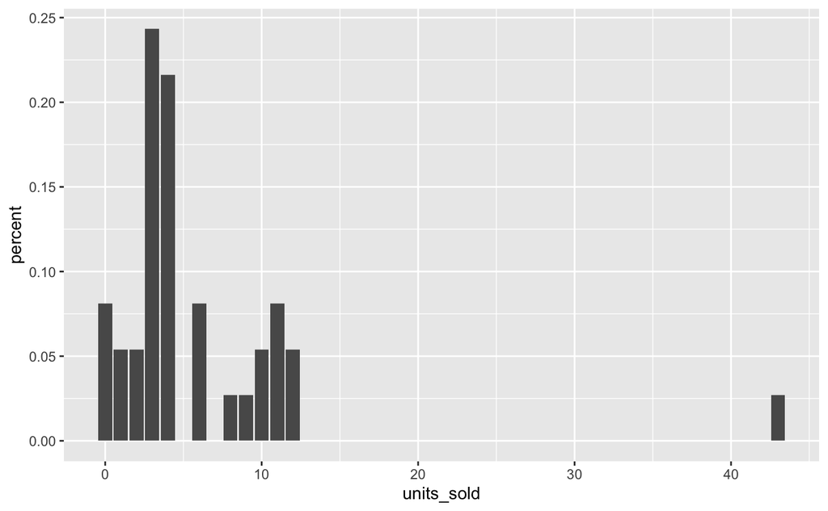

```r
sales_freq %>%
  ggplot(aes(x = units_sold,
             y = percent)) +
  geom_col()
```

Mean = sum of values / n of values

$$\mu = population$$

$$\bar{x} = sample$$

| mean_daily_sales |
| --- |
| 5.945946 |

Median = middle value of sorted values

[0, 3, 5, 2, 7, 8]

[0, 2, 3, 5, 7, 8]

median = 4

```r
aircon %>%
  summarise(median = median(units_sold))
```

| median |
| --- |
| 4 |

Mode = the most frequent value in the data

Mode function:

```r
get_mode <- function(data){

  tabled_data <- table(data)
  table_names <- names(tabled_data)

  return( table_names[tabled_data == max(tabled_data)] )

}
```

```r
aircon %>%
  summarise(mode = get_mode(units_sold))
```

| mode |
| --- |
| 3 |

A bit of dispute over where the *middle* of our distribution is

mean = 6 median = 4 mode = 3

Which one is *correct*?

The *mean* is the most likely to be affected by *extreme outliers*

This illustrates that: > It is very important to visualise your distribution and look at it

Distribution Shapes (Modality)

How many modes does the distribution have?

- one mode (one peak) = unimodal
- two modes (two peaks) = bimodal

Skewness = the asymmetry of a distribution

> left skewed (tail of distribution points left) - mean is being skewed to the left right skewed (tail of distribution points right) - mean is being skewed to the right symmetric (neither left or right skewed)

We can quantify skew (express numerically)

```r
library(e1071)
```

When quantifying skew, we can use the following class table

| magnitude | classification |
| --- | --- |
| < 0.5 | fairly symmetric |
| 0.5 - 1.0 | moderately skewed |
| > 1.0 | highly skewed |

| direction | classification |
| --- | --- |
| negative | left skew |
| positive | right skew |

Example: > skew = -0.8 (moderately left skewed) > skew = 1.2 (highly right skewed)

using `{e1071}` to calculate skew use Type 1

```r
aircon %>%
  summarise(
    skew = skewness(units_sold, type = 1)
  )
```

| skew |
| --- |
| 3.824317 |

> Always visualise the data *before* performing any further statistical analysis